# Milestone 6

Amanda Su

4/3/2020

# Intro

# Overview of Replication Paper

The authors of the paper “Race, Writing, and Computation: Racial Difference and the US Novel, 1880-2000” seek to implement a computational study of race that explores how computation can present new opportunities for thinking about racial difference and its patterns and regularities at scale. They develop a case study that focuses on race, religion, and the United States novel and build a model that tests if novelists marked as “white” versus “black” produce different narratological effects with respect to the interaction of race and religious authority, in particular, the authority of the Bible. In simpler terms, do writers identified as racially different contextualize the Bible in different ways in their novels? Then, the authors identify a set of general patterns in these effects that they interpret through the model’s reliance on concrete categories of racial identity. The ultimate aim of this is to propose a method for deforming this very categorical thinking. The authors’ logistic regression model reveals the relationship of race, gender, and biblical citation to the “sociality” of contexts where the Bible is quoted. That is, they model the relationship between the “Bible” and “race” variables to determine what are the odds of a Bible context being “social” increases or decreases based on the race variable, the options being “white” or “black.” For the purposes of this paper, moments of sociality, are defined as the presence of two or more characters engaged in dialogue or interaction. The question at hand is how a writer’s identity as “white” or “black” significantly changes the likelihood that the scene of their citation of the Bible in their work is “social”. The study ultimately finds that when a white writer quotes the Bible, it is less likely that she/he quotes it in a social context compared to when she/he writes about non-Bible related topics. However, when a black writer quotes the Bible, it is more likely that she/he quotes it in a social context.

# Graphic

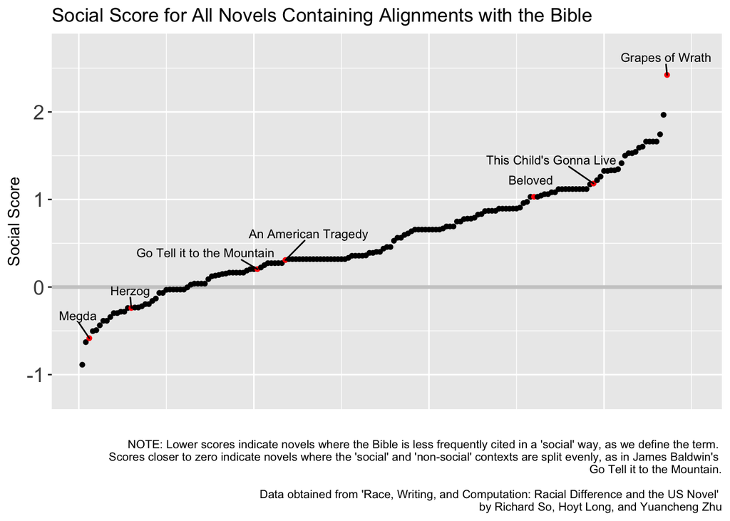

# Appendix

**Table 1: Summary**

| categories | sourcematchcontext | prop |
| --- | --- | --- |
| Aphorism/Saying | easier for a camel to pass through the eye of a needle, than for a rich man to enter | 0.02286282 |
| Juridical | truth, the whole truth, and nothing but the truth, so help me God | 0.04572565 |
| Lyric | Steal away, steal away, Steal away to Jesus; Steal away, steal away home, I ain’t got long to stay | 0.12326044 |
| Onomatopoeia | Yis, yis, yis! Yis, yis, yis! Yis | 0.01888668 |
| Quotation | fine the spirit of the Nation was; what unity of purpose, what untiring zeal! What elevation of purpose ran through all its splendid display of strength, its untiring accomplishment. I have said that … | 0.06759443 |
| Religious | Father who art in Heaven-hallowed be Thy name. Thy Kingdom come, Thy will be done | 0.12922465 |
| Self-Citation | standing at the back door, having already knocked. She could see his face through the glass panes. She put a hand out to the wall to steady herself | 0.04274354 |

**Table 2: Model 1**

| term | estimate | std.error |
| --- | --- | --- |
| (Intercept) | 0.905 | 0.347 |
| gender | -0.713 | 0.342 |
| race | -0.334 | 0.290 |
| bible | -2.272 | 0.488 |
| gender:bible | 0.856 | 0.480 |
| race:bible | 2.210 | 0.416 |

**Table 3: Model 2**

| term | estimate | std.error | statistic | p.value |
| --- | --- | --- | --- | --- |
| (Intercept) | 0.520 | 0.265 | 1.966 | 0.049 |
| gender | -0.313 | 0.236 | -1.322 | 0.186 |
| race | -0.220 | 0.252 | -0.871 | 0.384 |
| bible | -1.328 | 0.222 | -5.994 | 0.000 |
| race:bible | 1.742 | 0.355 | 4.904 | 0.000 |

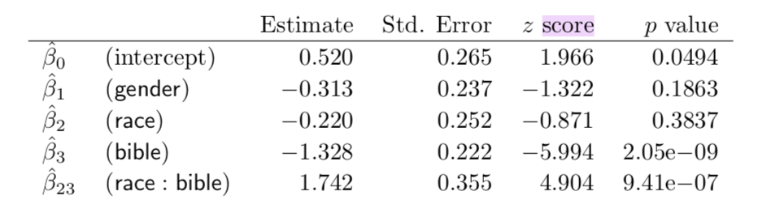

Screenshot of Table.

**Table 4: Predicted Probabilities**

| race | gender | bible | prop | prop_not | odds |
| --- | --- | --- | --- | --- | --- |
| white | female | yes | 0.938 | 0.062 | 15.000 |
| white | female | no | 0.733 | 0.267 | 2.750 |
| white | male | yes | 0.961 | 0.039 | 24.750 |
| white | male | no | 0.816 | 0.184 | 4.421 |
| black | female | yes | 0.875 | 0.125 | 7.000 |
| black | female | no | 0.864 | 0.136 | 6.333 |
| black | male | yes | 0.800 | 0.200 | 4.000 |
| black | male | no | 0.821 | 0.179 | 4.600 |

While I attempted replicating the tables and figures from the original paper, I realized that many of the results my tables yielded were not the same as the ones generated by the authors. To start, the values in table 1 (summary table) were just slightly off. I wasn’t able to identify the reason why, though it could likely be an error in my calculations or approach to replicating the table. Table 2 displays the results of a model that explains whether or not the context in which the bible is referenced in a text is “social” as a function of the race of the author, the author’s gender, whether or not the bible is referenced as a control variable, and the interaction between race and bible and the interaction between gender and bible. My results for this table were different from that of the authors’ because I decided to use stan_glmer to create the model as opposed to glmer, which is what the authors used. The family of lmer functions are used when you have a mixed model with a random variable, which in this case was the title or novel variable. stan_glmer is similar to glmer but with various possible prior distributions for the coefficients. I chose to use stan_glmer because it perfoms a full Bayesian estimation as opposed to just a maximum likelihood estimation of generalized linear models. Table 3 is a simpler model that answers the key question of interest: how the race of an author affects the context in which they write about the bible in their work. The model explains the social variable as a function of race, gender, bible (as a control), and the interaction between race and bible. For the purposes of verifying the authors’ results, I decided to use glmer when replicating this model and found that our results were the same. I then attempted to create a table that displayed the fitted, predicted probabilities of the various conditions based on the model. The results in table 4 of these predictions were not the same as that of the authors. I can’t to say their results are incorrect primarily because I struggled in the process of replicating this table and could very well have made a mistake. I’m hoping to seek further guidance and advice from Alice, Jack, or Enxhi to verify my approach to these calculations before I make any conclusions.

**Proposed Extension**

# References

Earhart, Amy. 2015. *Traces of the Old, Uses of the New*. Ann Arbor, MI: University of Michigan Press.

Jarrett, Gene Andrew. 2007. “Addition by Subtraction: Toward a Literary History of Racial Representation.” Legacy.

So, Richard Jean, Hoyt Long, and Yuancheng Zhu. 2019. “Race, Writing, and Computation: Racial Difference and the Us Novel, 1880-2000.” Journal of Cultural Analytics.

Spillers, Hortense. 2003. *Black, White, and in Color: Essays on American Literature and Culture*. Chicago: University of Chicago Press.

Stepto, Robert. 2001. *From Behind the Veil: A Study of Afro-American Narrative*. Urbana, IL: University of Illinois Press.

[^1]: All analysis for this paper is available at my [Github repository](https://github.com/amanda-y-su/race-writing-computation)